# Assignment 1 Exploratory Data Analysis

Jin Hyun,Kim 11968850 Ee June, Kim 11630566 Seungwoo,Hong 10879420

The codes illustrate the relationship among adult dataset which is available in the R liver package via exploratory data analysis (EDA). The adult dataset contains 15 variables. Through this assignment, each data would be discussed and visualized.

## Load ‘ggplot2’, ‘liver’, ‘ROCR’ packages

```r
require( ggplot2 )   # load the package "ggplot2"
require( liver   )   # load the package "liver"
require( ROCR    )   # load the package "ROCR"

library(ggplot2)
library(plyr)
library(ROCR)
```

#load data

```r
data("adult")
```

###EDA of the dependent variable

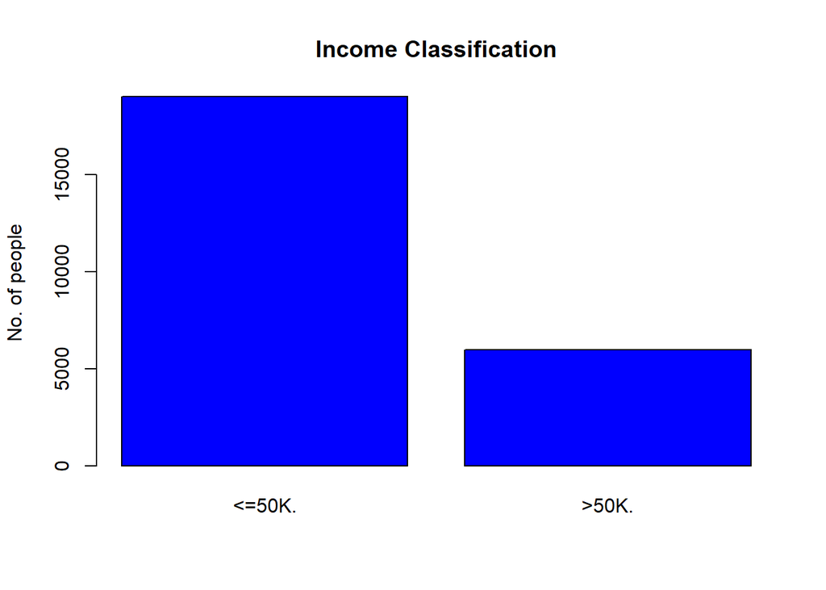

```r
barplot(table(adult$income),main = 'Income Classification',col='blue',ylab ='No. of people')
```

### The summary of the dataset

```r
summary( adult )
```

```
##       age                   workclass      demogweight             education
##  Min.   :17.00   Private         :17385   Min.   :  12285   HS-grad     :8120
##  1st Qu.:28.00   Self-emp-not-inc: 1978   1st Qu.: 117963   Some-college:5597
##  Median :37.00   Local-gov       : 1624   Median : 178353   Bachelors   :4140
##  Mean   :38.61   ?               : 1399   Mean   : 189742   Masters     :1300
##  3rd Qu.:48.00   State-gov       :  993   3rd Qu.: 236861   Assoc-voc   :1059
##  Max.   :90.00   Self-emp-inc    :  857   Max.   :1484705   11th        : 909
##                  (Other)         :  764                     (Other)     :3875
##  education.num                 marital.status            occupation
##  Min.   : 1.00   Divorced             : 3435   Prof-specialty :3180
##  1st Qu.: 9.00   Married-AF-spouse    :   16   Craft-repair   :3122
##  Median :10.00   Married-civ-spouse   :11441   Exec-managerial:3084
##  Mean   :10.08   Married-spouse-absent:  328   Adm-clerical   :2975
##  3rd Qu.:12.00   Never-married        : 8225   Sales          :2815
##  Max.   :16.00   Separated            :  786   Other-service  :2555
##                  Widowed              :  769   (Other)        :7269
##          relationship                   race           sex
##  Husband       :10064   Amer-Indian-Eskimo:  241   Female: 8291
##  Not-in-family : 6443   Asian-Pac-Islander:  775   Male  :16709
##  Other-relative:  729   Black             : 2379
##  Own-child     : 3911   Other             :  214
##  Unmarried     : 2640   White             :21391
##  Wife          : 1213
##
##   capital.gain    capital.loss    hours.per.week        native.country
##  Min.   :    0   Min.   :   0.0   Min.   : 1.00   United-States:22421
##  1st Qu.:    0   1st Qu.:   0.0   1st Qu.:40.00   Mexico       :  488
##  Median :    0   Median :   0.0   Median :40.00   ?            :  445
##  Mean   : 1089   Mean   :  86.5   Mean   :40.41   Philippines  :  151
##  3rd Qu.:    0   3rd Qu.:   0.0   3rd Qu.:45.00   Germany      :  102
##  Max.   :99999   Max.   :4356.0   Max.   :99.00   Canada       :   99
##                                                   (Other)      : 1294
##     income
##  <=50K.:19016
##  >50K. : 5984
##
##
##
##
##
```

### The structure of the data

```r
str( adult )
```

```
## 'data.frame':    25000 obs. of  15 variables:
##  $ age           : int  39 50 38 53 28 37 49 52 31 42 ...
##  $ workclass     : Factor w/ 9 levels "?","Federal-gov",..: 8 7 5 5 5 5 5 7 5 5 ...
##  $ demogweight   : int  77516 83311 215646 234721 338409 284582 160187 209642 45781 159449 ...
##  $ education     : Factor w/ 16 levels "10th","11th",..: 10 10 12 2 10 13 7 12 13 10 ...
##  $ education.num : int  13 13 9 7 13 14 5 9 14 13 ...
##  $ marital.status: Factor w/ 7 levels "Divorced","Married-AF-spouse",..: 5 3 1 3 3 3 4 3 5 3 ...
##  $ occupation    : Factor w/ 15 levels "?","Adm-clerical",..: 2 5 7 7 11 5 9 5 11 5 ...
##  $ relationship  : Factor w/ 6 levels "Husband","Not-in-family",..: 2 1 2 1 6 6 2 1 2 1 ...
##  $ race          : Factor w/ 5 levels "Amer-Indian-Eskimo",..: 5 5 5 3 3 5 3 5 5 5 ...
##  $ sex           : Factor w/ 2 levels "Female","Male": 2 2 2 2 1 1 1 2 1 2 ...
##  $ capital.gain  : int  2174 0 0 0 0 0 0 0 14084 5178 ...
##  $ capital.loss  : int  0 0 0 0 0 0 0 0 0 0 ...
##  $ hours.per.week: int  40 13 40 40 40 40 16 45 50 40 ...
##  $ native.country: Factor w/ 42 levels "?","Cambodia",..: 40 40 40 40 6 40 24 40 40 40 ...
##  $ income        : Factor w/ 2 levels "<=50K.",">50K.": 1 1 1 1 1 1 1 2 2 2 ...
```

### Explanations of variables

- age: The age of an individual (Type: Numerical and discrete)
- workclass: A general term to represent the employment status of an individual. (Type: Categorical and nominal)
- education: The highest level of education achieved by an individual. (Type: Categorical and nominal)
- education.num: The highest level of education achieved in numerical form. (Type: Numerial and discrete)
- marital.status: Marital status of an individual. Married.civ.spouse corresponds to a civilian spouse while Married.AF.spouse is a spouse in the Armed Forces. (Type: Categorical and nominal)
- occupation: the general type of occupation of an individual (Type: Categorical and nominal)
- relationship: Represents what this individual is relative to others. For example an individual could be a Husband. Each entry only has one relationship attribute and is somewhat redundant with marital status. We might not make use of this attribute at all (Type: Categorical and nominal )
- race: Descriptions of an individual’s race (Type: Categorical and nominal )
- sex: the biological sex of the individual (Type: Categorical and binary )
- capital.gain: capital gains for an individual (Type: Numerical and continuous)
- capital.loss: capital loss for an individual (Type: Numerical and continuous)
- hours.per.week: the hours an individual has reported to work per week (Type: Numerial and discrete)
- native.country: country of origin for an individual (Type: Categorical and nominal )
- ? : missing variables.
- the label: whether or not an individual makes more than $50,000 annually.

  ```
       * <=50k
       * >50k
  ```

  (Type: Categorical and binary )

### Concluding a few things before applying the various classification algorithms

```r
adult$educatoin <- NULL
adult$relationship <- NULL
```

###Checking income with respect to age

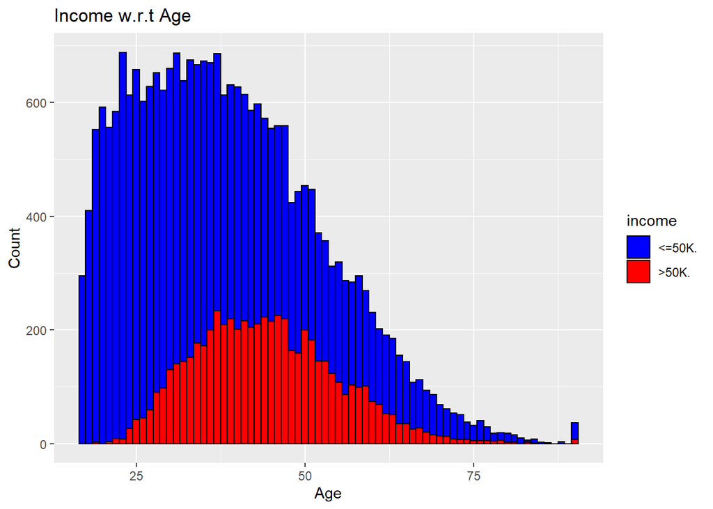

```r
ggplot(adult) + aes(x=as.numeric(age), group=income, fill=income) +
  geom_histogram(binwidth=1, color='black')+
  labs(x="Age",y="Count",title = "Income w.r.t Age")+
  scale_fill_manual( values = c( "blue", "red" ) )
```

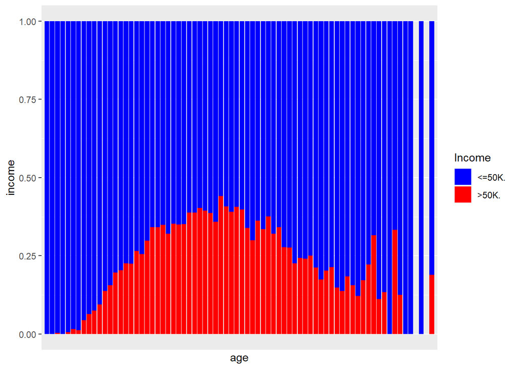

```r
ggplot() +
  geom_bar( data = adult,
            aes( x    = as.numeric( age ),
                 fill = factor( income ) ),
            position = "fill" ) +
  scale_x_discrete( "age" ) +
  scale_y_continuous( "income" ) +
  guides( fill = guide_legend( title = "Income" ) ) +
  scale_fill_manual( values = c( "blue", "red" ) )
```

As we notice total incomes mostly come from 20- 40 ages. On the other hand, It can be checked that middle aged people show the highest proportion of 50k> income earnings. We can conclude that age has a correlation with income. Before middle age, age has a positive impact. However after that, age has a negative effect on income. The reason behind this rise and fall could be promotion on workplace and retirement

###Checking income with respect to gender group

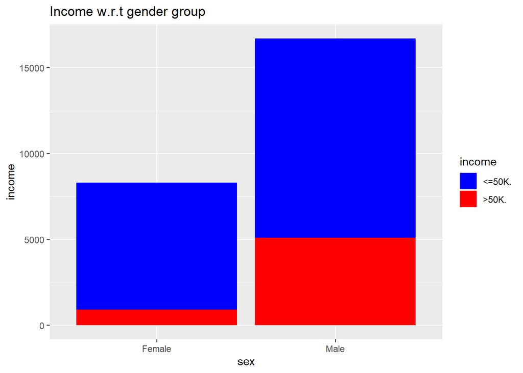

```r
ggplot() +
  geom_bar( data = adult,
            aes( x    = factor( sex ),
                 fill = factor( income ) ),
            position = "stack" ) +
  scale_x_discrete( "sex" ) +
  scale_y_continuous( "income" ) +
  guides( fill = guide_legend( title = "income " ) ) +
  scale_fill_manual( values = c( "blue", "red" ) ) +
  labs(x="Age",y="Count",title = "Income w.r.t gender group")
```

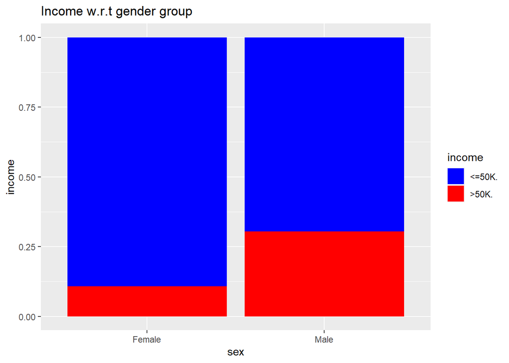

```r
ggplot() +
  geom_bar( data = adult,
            aes( x    = factor( sex ),
                 fill = factor( income ) ),
            position = "fill" ) +
  scale_x_discrete( "sex" ) +
  scale_y_continuous( "income" ) +
  guides( fill = guide_legend( title = "income" ) ) +
  scale_fill_manual( values = c( "blue", "red" ) )  +
  labs(x="Age",y="Count",title = "Income w.r.t gender group")
```

Addtionally, it can be checked that proportion of male who earns more than 50k is higher than that of female. So, we can conclude that sex has an effect on income. Although working conditions for women is generally getting better and better than before, we can still see that males are getting paid more than women. Possible reasons for this gap could be preference of male in workplace, disadvatage from childbirth, etc

###Checking income with respect to workclass

### Not normalized

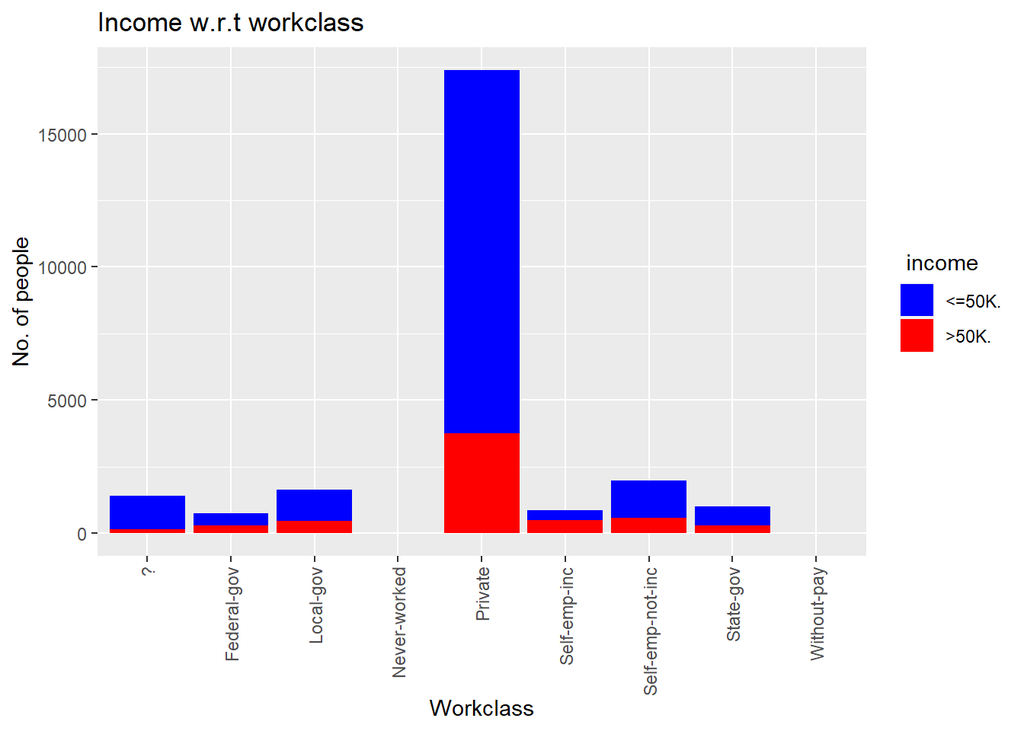

```r
ggplot() +
  geom_bar( data = adult,
            aes( x    = factor( workclass ),
                 fill = factor( income ) ),
            position = "stack" ) +
  scale_x_discrete( "Workclass" ) +
  scale_y_continuous( "No. of people" ) +
  guides( fill = guide_legend( title = " income" ) ) +
  scale_fill_manual( values = c( "blue", "red" ) ) + theme(axis.text.x = element_text(angle = 90, vjust = 0.5, hjust=1)) +
  labs(x="Age",y="Count",title = "Income w.r.t workclass")
```

### Normalized

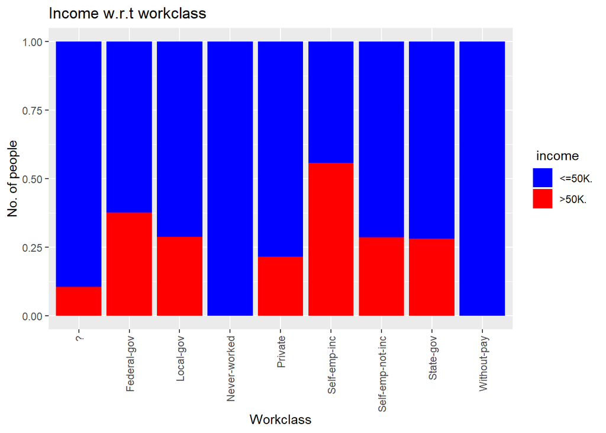

```r
ggplot() +
  geom_bar( data = adult,
            aes( x    = factor( workclass ),
                 fill = factor( income ) ),
            position = "fill" ) +
  scale_x_discrete( "Workclass" ) +
  scale_y_continuous( "No. of people" ) +
  guides( fill = guide_legend( title = " income" ) ) +
  scale_fill_manual( values = c( "blue", "red" ) ) + theme(axis.text.x = element_text(angle = 90, vjust = 0.5, hjust=1)) +
  labs(x="Age",y="Count",title = "Income w.r.t workclass")
```

# Not normalized

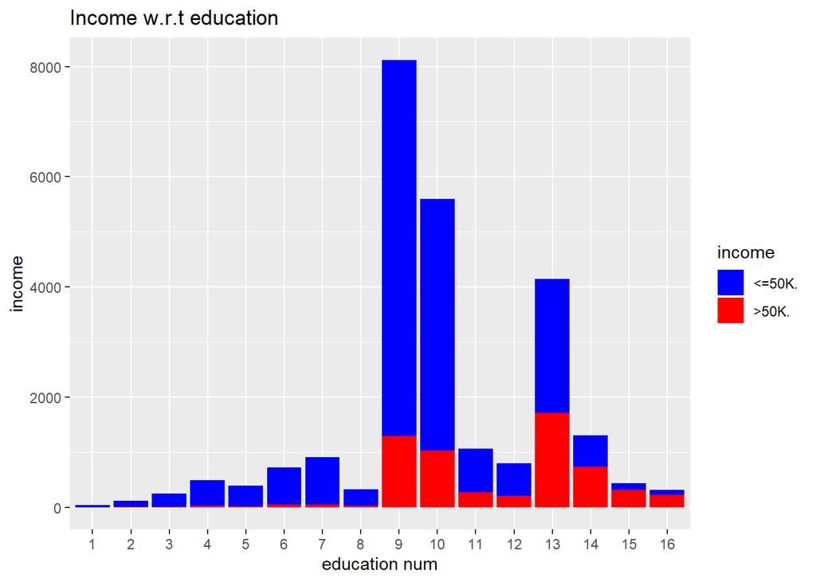

```r
ggplot() +
  geom_bar( data = adult,
            aes( x    = factor( education.num ),
                 fill = factor( income ) ),
            position = "stack" ) +
  scale_x_discrete( "education num" ) +
  scale_y_continuous( "income" ) +
  guides( fill = guide_legend( title = "income " ) ) +
  scale_fill_manual( values = c( "blue", "red" ) ) +
  labs(x="Age",y="Count",title = "Income w.r.t education")
```

# Normalized

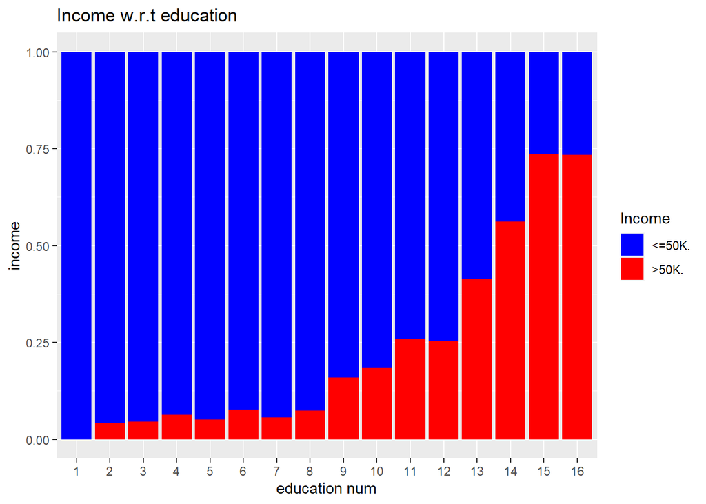

```r
ggplot() +
  geom_bar( data = adult,
            aes( x    = factor( education.num ),
                 fill = factor( income ) ),
            position = "fill" ) +
  scale_x_discrete( "education num" ) +
  scale_y_continuous( "income" ) +
  guides( fill = guide_legend( title = "Income " ) ) +
  scale_fill_manual( values = c( "blue", "red" ) ) +
  labs(x="Age",y="Count",title = "Income w.r.t education")
```

It can be seen that the total incomes are highest when the education num is between 9 and 10. However, it is shown that a longer education duration leads to higher income from the second graph.

The reason behind this correlation difference could be that general job requirements are usually fulfilled with 9- 10 years education levels. Although jobs that requires long education period allow high earnings, the number of these special jobs is generally not that high. The less number of special job probably has caused less total income amount.

Briefly, education num has a positive correlation with income.

### Occupation

```r
summary(adult$occupation)
```

```
##                 ?      Adm-clerical      Armed-Forces      Craft-repair
##              1404              2975                 7              3122
##   Exec-managerial   Farming-fishing Handlers-cleaners Machine-op-inspct
##              3084               767              1000              1536
##     Other-service   Priv-house-serv    Prof-specialty   Protective-serv
##              2555               121              3180               503
##             Sales      Tech-support  Transport-moving
##              2815               703              1228
```

For simplicity of the model, occupation is also blocked into several groups, namely Blue-Collar, Professional, Sales, Service, and White-Collar. Because of the small number of people who are service members, they are combined with Unknowns to form an Unknown/Other group.

```r
levels(adult$occupation)[1] <- 'Unknown'
adult$occupation <- gsub('Adm-clerical', 'White-Collar', adult$occupation)
adult$occupation <- gsub('Craft-repair', 'Blue-Collar', adult$occupation)
adult$occupation <- gsub('Exec-managerial', 'White-Collar', adult$occupation)
adult$occupation <- gsub('Farming-fishing', 'Blue-Collar', adult$occupation)
adult$occupation <- gsub('Handlers-cleaners', 'Blue-Collar', adult$occupation)
adult$occupation <- gsub('Machine-op-inspct', 'Blue-Collar', adult$occupation)
adult$occupation <- gsub('Other-service', 'Service', adult$occupation)
adult$occupation <- gsub('Priv-house-serv', 'Service', adult$occupation)
adult$occupation <- gsub('Prof-specialty', 'Professional', adult$occupation)
adult$occupation <- gsub('Protective-serv', 'Service', adult$occupation)
adult$occupation <- gsub('Tech-support', 'Service', adult$occupation)
adult$occupation <- gsub('Transport-moving', 'Blue-Collar', adult$occupation)
adult$occupation <- gsub('Unknown', 'Other/Unknown', adult$occupation)
adult$occupation <- gsub('Armed-Forces', 'Other/Unknown', adult$occupation)
adult$occupation <- as.factor(adult$occupation)
summary(adult$occupation)
```

```
##   Blue-Collar Other/Unknown  Professional         Sales       Service
##          7653          1411          3180          2815          3882
##  White-Collar
##          6059
```

# Create a dataframe

```r
df2 <- data.frame(table(adult$income, adult$occupation))
names(df2) <- c('income', 'occupation', 'count')
df2
```

```
##    income    occupation count
## 1  <=50K.   Blue-Collar  6358
## 2   >50K.   Blue-Collar  1295
## 3  <=50K. Other/Unknown  1263
## 4   >50K. Other/Unknown   148
## 5  <=50K.  Professional  1758
## 6   >50K.  Professional  1422
## 7  <=50K.         Sales  2064
## 8   >50K.         Sales   751
## 9  <=50K.       Service  3395
## 10  >50K.       Service   487
## 11 <=50K.  White-Collar  4178
## 12  >50K.  White-Collar  1881
```

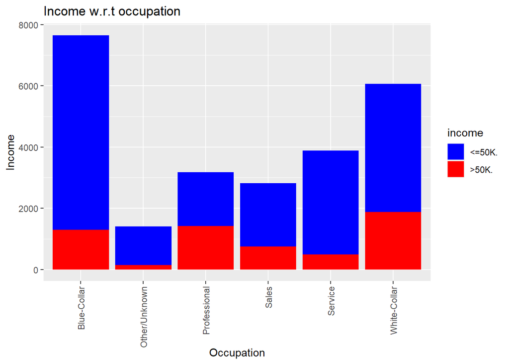

```r
ggplot() +
  geom_bar( data = adult,
            aes( x    = factor( occupation ),
                 fill = factor( income ) ),
            position = "stack" ) +
  scale_x_discrete( "Occupation" ) +
  scale_y_continuous( "Income" ) +
  guides( fill = guide_legend( title = "income " ) ) +
  scale_fill_manual( values = c( "blue", "red" ) ) +
  labs(x="Age",y="Count",title = "Income w.r.t occupation")+ theme(axis.text.x = element_text(angle = 90, vjust = 0.5, hjust=1))
```

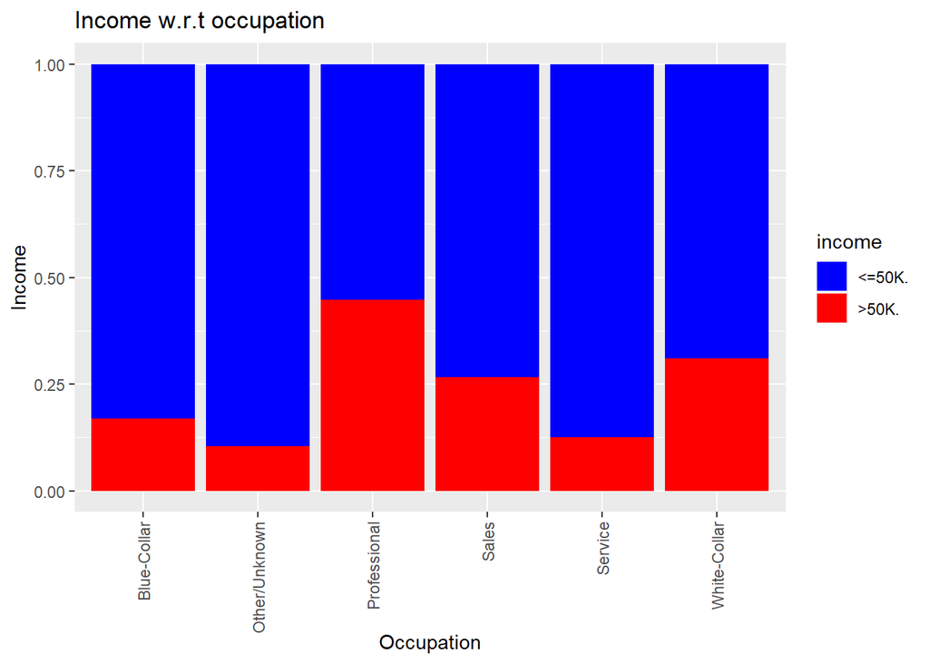

```r
ggplot() +
  geom_bar( data = adult,
            aes( x    = factor( occupation ),
                 fill = factor( income ) ),
            position = "fill" ) +
  scale_x_discrete( "Occupation" ) +
  scale_y_continuous( "Income" ) +
  guides( fill = guide_legend( title = "income " ) ) +
  scale_fill_manual( values = c( "blue", "red" ) ) +
  labs(x="Age",y="Count",title = "Income w.r.t occupation")+ theme(axis.text.x = element_text(angle = 90, vjust = 0.5, hjust=1))
```

Briefly, occupations are correlated with income.

### Marital_status

marital_status is a categorical variable with 7 categories indicating the marital status of observations. In fact, it can be blocked into a few categories as well.

```r
summary(adult$marital.status)
```

```
##              Divorced     Married-AF-spouse    Married-civ-spouse
##                  3435                    16                 11441
## Married-spouse-absent         Never-married             Separated
##                   328                  8225                   786
##               Widowed
##                   769
```

```r
adult$marital.status <- gsub('Married-AF-spouse', 'Married', adult$marital.status)
adult$marital.status <- gsub('Married-civ-spouse', 'Married', adult$marital.status)
adult$marital.status <- gsub('Married-spouse-absent', 'Married', adult$marital.status)
adult$marital.status <- gsub('Never-married', 'Single', adult$marital.status)
```

## Not normalized

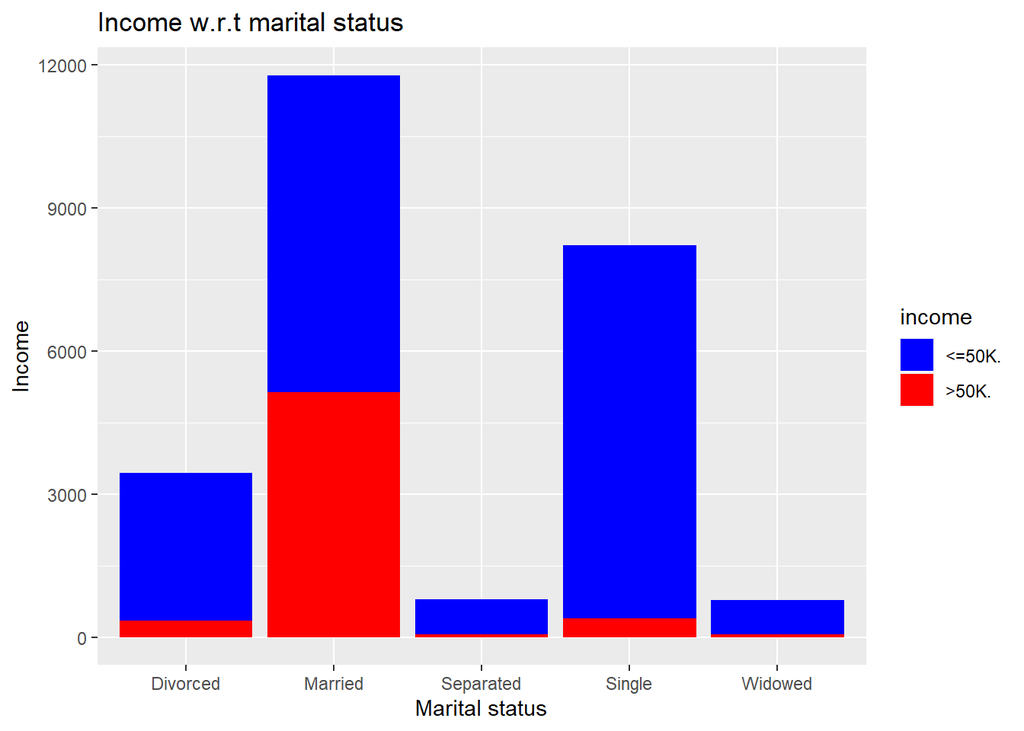

```r
ggplot() +
  geom_bar( data = adult,
            aes( x    = factor( marital.status ),
                 fill = factor( income ) ),
            position = "stack")+
  scale_x_discrete( "Marital status" ) +
  scale_y_continuous( "Income" ) +
  guides( fill = guide_legend( title = "income" ) ) +
  scale_fill_manual( values = c( "blue", "red" ) ) +
  labs(x="Age",y="Count",title = "Income w.r.t marital status")
```

It is shown that income from married couple is the largest among five groups.

##Normalized

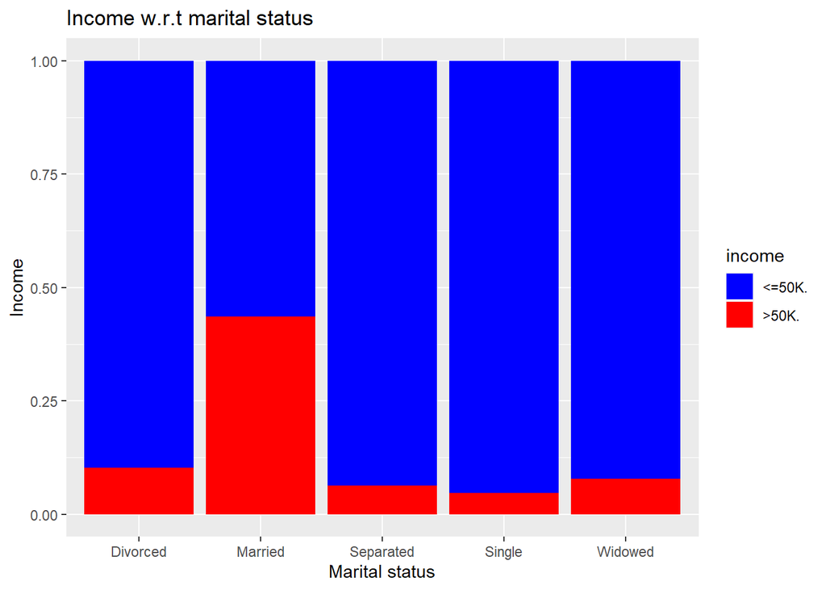

```r
ggplot() +
  geom_bar( data = adult,
            aes( x    = factor( marital.status ),
                 fill = factor( income ) ),
            position = "fill" ) +
  scale_x_discrete( "Marital status" ) +
  scale_y_continuous( "Income" ) +
  guides( fill = guide_legend( title = "income" ) ) +
  scale_fill_manual( values = c( "blue", "red" ) ) +
  labs(x="Age",y="Count",title = "Income w.r.t marital status")
```

From barplots above, variable “marital status” seems to have an association with the target variable “income”. Nearly half of the observations that are currently married have an income more than 50K, while observations with other status show that more than 80 % of people have an income of less than 50K. The proportion of people having an income of 50K or more was shown smallest in a group of no marriage experience.

The high income from married couples can be explained with the possibility of married couples working together.

## Not normalized

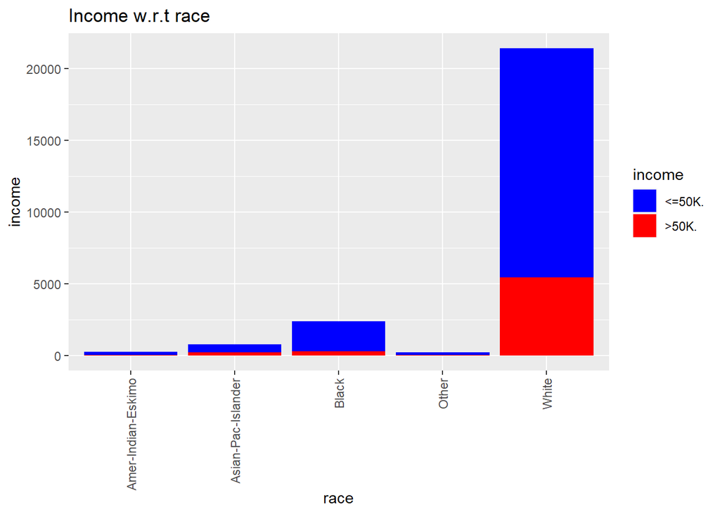

```r
ggplot() +
  geom_bar( data = adult,
            aes( x    = factor( race ),
                 fill = factor( income ) ),
            position = "stack") +
  scale_x_discrete( "race" ) +
  scale_y_continuous( "income" ) +
  guides( fill = guide_legend( title = "income" ) ) +
  scale_fill_manual( values = c( "blue", "red" ) ) +
  labs(x="Age",y="Count",title = "Income w.r.t race")+ theme(axis.text.x = element_text(angle = 90, vjust = 0.5, hjust=1))
```

It can be seen that total income from White is the largest among all races. The distribution of variable ‘race’ explains that there are 5 unique categories, and most of them are “white” which is roughly 85.5% with the second major race “black” (9.59%). It is important to notice that the dataset is biased toward the specific race “white”.

## Normalized

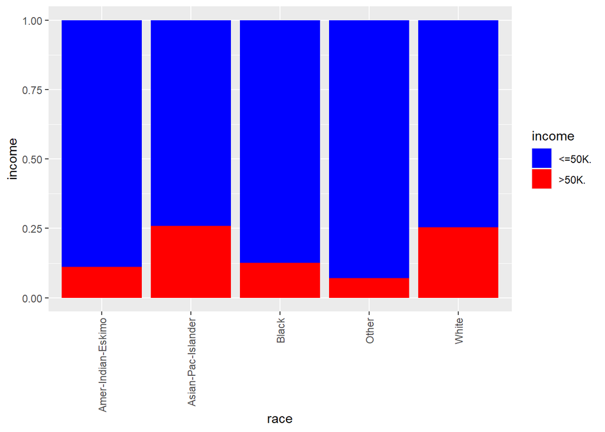

```r
ggplot() +
  geom_bar( data = adult,
            aes( x    = factor( race ),
                 fill = factor( income ) ),
            position = "fill" ) +
  scale_x_discrete( "race" ) +
  scale_y_continuous( "income" ) +
  guides( fill = guide_legend( title = "income" ) ) +
  scale_fill_manual( values = c( "blue", "red" ) ) + theme(axis.text.x = element_text(angle = 90, vjust = 0.5, hjust=1))
```

It is illustrated that ‘Asian- Pac- islander’ and ‘White’ equally have the highest proportion of over 50k income earner. Since the plot shows that there are clear income gap between races, variable ‘race’ has an impact on a dependent variable.

### Capital_gain & Capital_loss

#### Scatter Plot

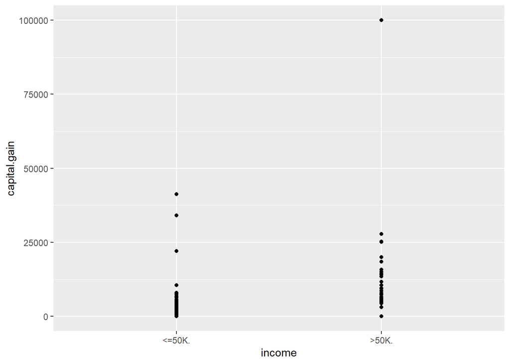

```r
ggplot(adult, aes(x = income, y = capital.gain)) +
  geom_point()
```

# histogram of capital_gain

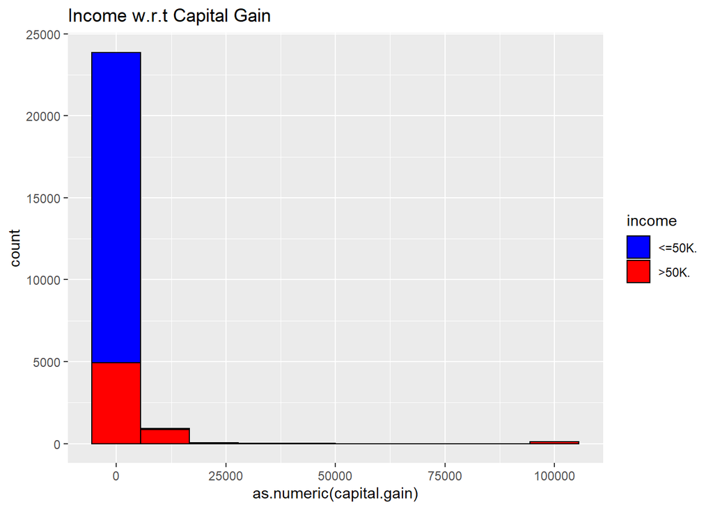

```r
ggplot(adult) + aes(x=as.numeric(capital.gain), group=income, fill=income) +
  geom_histogram(bins=10, color='black') + ggtitle('Income w.r.t Capital Gain')+
  scale_fill_manual( values = c( "blue", "red" ) )
```

#### Re-labeling & Bar plots

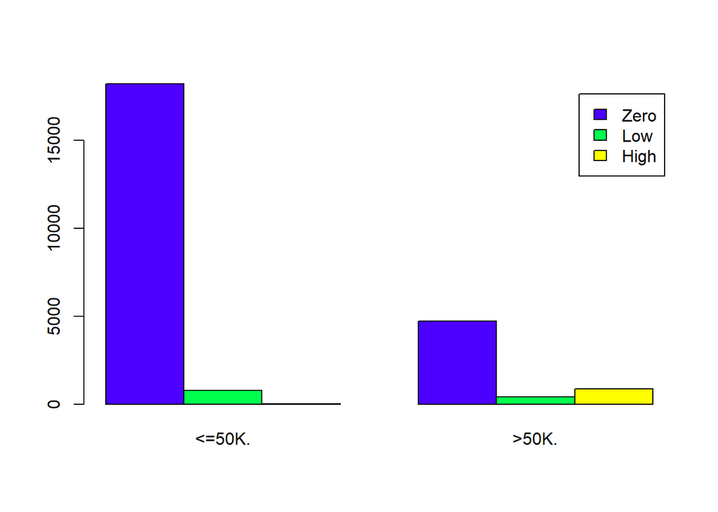

```r
capital.gain.median <-
  median(subset(adult, capital.gain != 0)$capital.gain)
adult$capital.gain <-
  cut(
    adult$capital.gain,
    breaks = c(-Inf, 0, capital.gain.median,+Inf),
    labels = c("Zero", "Low", "High")
  )
tab <- table(adult$capital.gain, adult$income)
barplot(tab,
        beside = TRUE,
        col = topo.colors(nrow(tab)),
        legend = rownames(tab))
```

### Capital-loss and income

#### Scatter Plot

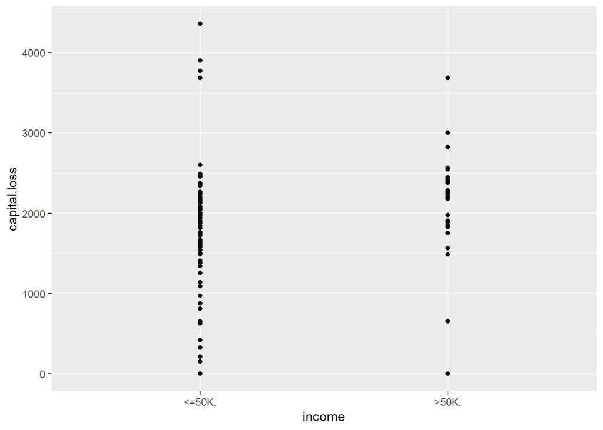

```r
ggplot(adult, aes(x = income, y = capital.loss)) +
  geom_point()
```

# histogram of capital_loss

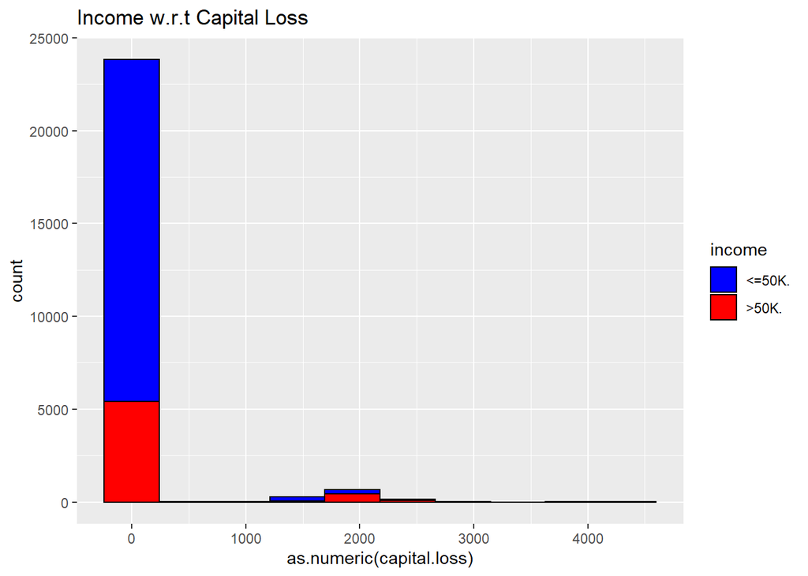

```r
ggplot(adult) + aes(x=as.numeric(capital.loss), group=income, fill=income) +
  geom_histogram(bins=10, color='black') + ggtitle('Income w.r.t Capital Loss')+
  scale_fill_manual( values = c( "blue", "red" ) )
```

#### Re-labeling & Bar plots

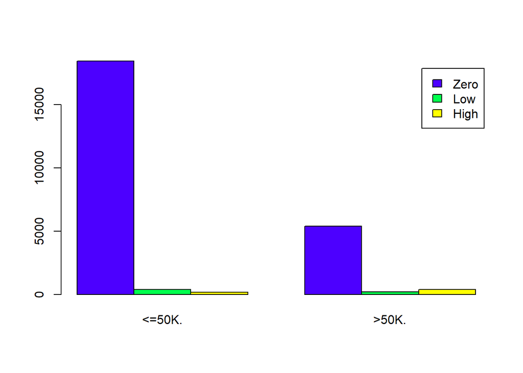

```r
capital.loss.median <-
  median(subset(adult, capital.loss != 0)$capital.loss)
adult$capital.loss <-
  cut(
    adult$capital.loss,
    breaks = c(-Inf, 0, capital.loss.median,+Inf),
    labels = c("Zero", "Low", "High")
  )
tab <- table(adult$capital.loss, adult$income)
barplot(tab,
        beside = TRUE,
        col = topo.colors(nrow(tab)),
        legend = rownames(tab))
```

Most of the observed values of capital gains and losses are accumulated at 0 for both income groups.

In the re-labeled boxplot, the capital gain was high in the group with income higher than 50k, but the capital loss was also higher in the same group.

```r
adult$capital.gain <- NULL
adult$capital.loss <- NULL
```

### Income with hours per week

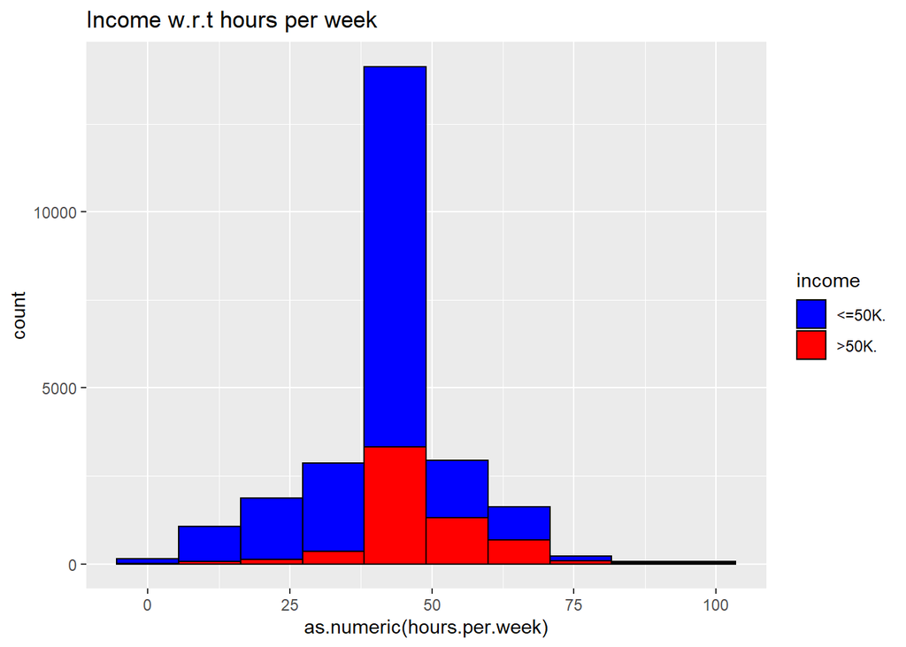

```r
ggplot(adult) + aes(x=as.numeric(hours.per.week), group=income, fill=income, position = "fill")+
  geom_histogram(bins=10, color='black') + ggtitle('Income w.r.t hours per week')+
  scale_fill_manual( values = c( "blue", "red" ) )
```

```r
tab <- table(adult$hours.per.week, adult$income)
tab
```

```
##
##      <=50K. >50K.
##   1      15     2
##   2      20     6
##   3      29     0
##   4      35     2
##   5      30     6
##   6      44     6
##   7      20     3
##   8     104    10
##   9      15     0
##   10    202    16
##   11      8     0
##   12    119     7
##   13     16     2
```

[output cut: 81 more lines]

#### Barplot

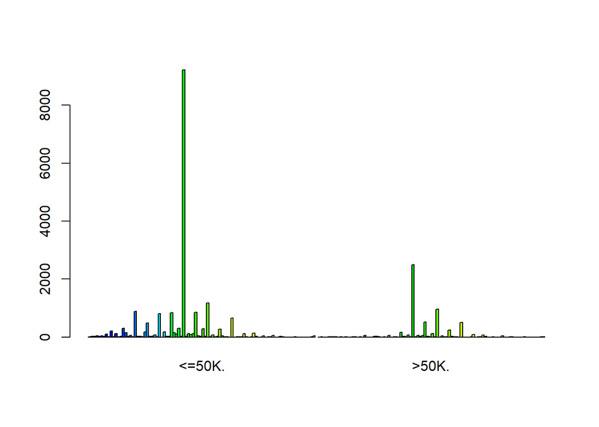

```r
barplot(tab, beside=TRUE, col=topo.colors(nrow(tab)))
```

Median of the “hours per week” seems higher in the income group >50K. In the group with income >50K, it seems to choose a slightly more flexible working hours, but the variable does not seem to be directly associated to the target variable income.

# Normalized

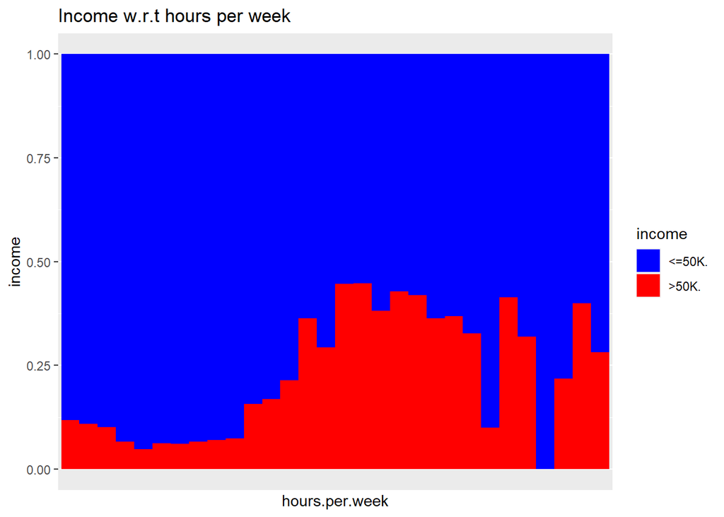

```r
ggplot() +
  geom_histogram( data = adult,
            aes( x    = as.numeric( hours.per.week ),
                 fill = factor( income ) ),
            position = "fill" ) +
  scale_x_discrete( "hours.per.week" ) +
  scale_y_continuous( "income" ) +
  guides( fill = guide_legend( title = "income " ) ) +
  scale_fill_manual( values = c( "blue", "red" ) ) +
  geom_histogram(bins=40, color='black')+ ggtitle('Income w.r.t hours per week')
```

### Native country

```r
summary(adult$native.country)
```

```
##                          ?                   Cambodia
##                        445                         16
##                     Canada                      China
##                         99                         60
##                   Columbia                       Cuba
##                         45                         72
##         Dominican-Republic                    Ecuador
##                         54                         19
##                El-Salvador                    England
##                         72                         72
##                     France                    Germany
##                         21                        102
##                     Greece                  Guatemala
##                         23                         50
##                      Haiti         Holand-Netherlands
##                         38                          1
##                   Honduras                       Hong
##                          8                         11
##                    Hungary                      India
##                         10                         67
##                       Iran                    Ireland
##                         35                         19
##                      Italy                    Jamaica
##                         55                         58
##                      Japan                       Laos
##                         48                          8
##                     Mexico                  Nicaragua
##                        488                         25
## Outlying-US(Guam-USVI-etc)                       Peru
##                          8                         23
##                Philippines                     Poland
##                        151                         49
##                   Portugal                Puerto-Rico
##                         28                         96
##                   Scotland                      South
##                          9                         64
##                     Taiwan                   Thailand
##                         42                         15
##            Trinadad&Tobago              United-States
##                         12                      22421
##                    Vietnam                 Yugoslavia
##                         50                         11
```

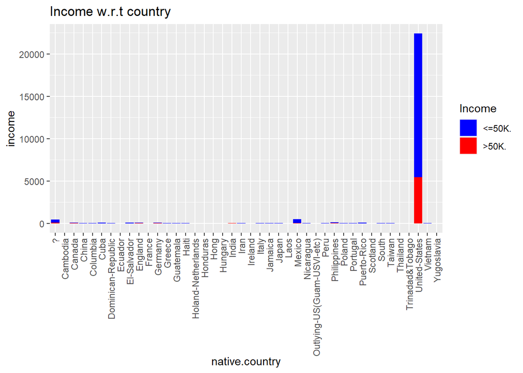

```r
ggplot() +
  geom_bar( data = adult,
            aes( x    = factor( native.country ),
                 fill = factor( income ) ),
            position = "stack" ) +
  scale_x_discrete( "native.country" ) +
  scale_y_continuous( "income" ) +
  guides( fill = guide_legend( title = "Income" ) ) +
  scale_fill_manual( values = c( "blue", "red" ) )+ ggtitle('Income w.r.t country') + theme(axis.text.x = element_text(angle = 90, vjust = 0.5, hjust=1))
```

It can be seen that the total income from U.S is the extremly highest among selected countries.

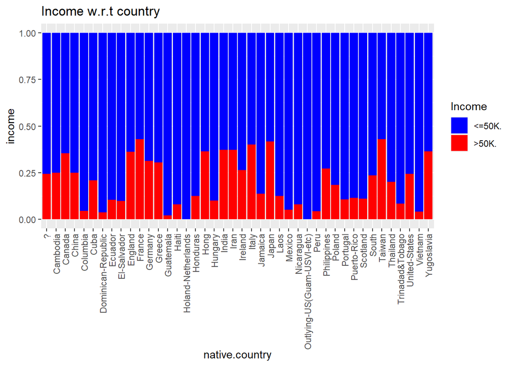

```r
ggplot() +
  geom_bar( data = adult,
            aes( x    = factor( native.country ),
                 fill = factor( income ) ),
            position = "fill" ) +
  scale_x_discrete( "native.country" ) +
  scale_y_continuous( "income" ) +
  guides( fill = guide_legend( title = "Income" ) ) +
  scale_fill_manual( values = c( "blue", "red" ) )+ ggtitle('Income w.r.t country') + theme(axis.text.x = element_text(angle = 90, vjust = 0.5, hjust=1))
```

### Summary

With these relationships between income and variables above, it could be concluded that the EDA helps to interpret the data by analysing and visualizing each variable from the data.